# Session 1: Basics in R (review)

Stephany Orjuela

November 13, 2018

## General remarks

Before you start working on a project, you should think about and decide on a directory structure. Also, if you have all your code saved in scripts, you can always rerun every step of the analysis.

Some general recommendations on working with R:

- Refresh your R session every time you start working on something new (In RStudio, Session .. Restart R).
- Organize your scripts into reasonable subunits (e.g., for different purposes/topics, create separate scripts)
- Try and use a consistent style in the way that you name variables, files and functions
- Use scripts to save code. Never save the workspace!
- Save only the R objects that will be needed later with `saveRDS()`; these can be loaded in a later script with `readRDS()`

We will use Rmarkdown to convert an Rscript to a report that includes text, code and figures all together into an HTML report (PDF can also be used). You can find some Rmarkdown basics [here](https://rmarkdown.rstudio.com/authoring_basics.html). See the following articles for a more detailed explanation of the [code chunk options](https://rmarkdown.rstudio.com/authoring_rcodechunks.html) and [pandoc markdown](https://rmarkdown.rstudio.com/authoring_pandoc_markdown.html)

# Obtaining the data

Our data will not always be on our computer. We must be able to obtain the data from wherever it is. We will download the data for this exercise from a github repository. To learn more about github click [here](https://guides.github.com/activities/hello-world/)

### For mac and unix users:

From your terminal, create a working directory for today’s session and move to it

```bash
mkdir BIO255
cd BIO255
```

Download the data to your computer with the following command

```bash
github clone https://github.com/sorjuela/BIO255-Cancer-Epigenetics.git
```

### For windows users:

- Go to `https://github.com/sorjuela/BIO255-Cancer-Epigenetics`
- Click on the `Clone or download` button, and select `Download ZIP`
- unzip the folder

# First steps in R (quick and dirty reminder)

### Data types and assignment

```r
a1 <- 2
a2 <- "abc"
a3 <- TRUE
```

### Simple computation

```r
3+2
```

```
## [1] 5
```

```r
3*2
```

```
## [1] 6
```

```r
3^2
```

```
## [1] 9
```

### Containers (1d)

```r
## Vector: Same data types
v <- c(1,2,3)

v # !!! automatic type conversion !!!
```

```
## [1] 1 2 3
```

```r
## generate vector
v <- c(21,22,23,24)
v <- 21:24 ## less typing
v <- seq(from=21,to=24,by=1)

## select by position
v[2]
```

```
## [1] 22
```

```r
v[-2]
```

```
## [1] 21 23 24
```

```r
v[1:3]
```

```
## [1] 21 22 23
```

```r
v[c(1,4)]
```

```
## [1] 21 24
```

```r
## select by value
v == 22
```

```
## [1] FALSE  TRUE FALSE FALSE
```

```r
v[v==22]
```

```
## [1] 22
```

```r
v<=22
```

```
## [1]  TRUE  TRUE FALSE FALSE
```

```r
v[v<=22]
```

```
## [1] 21 22
```

```r
v %in% c(21,24)
```

```
## [1]  TRUE FALSE FALSE  TRUE
```

```r
v[v %in% c(21,24)]
```

```
## [1] 21 24
```

```r
## list: different data types
l <- list(a="a", b=1, c=FALSE)
l
```

```
## $a
## [1] "a"
##
## $b
## [1] 1
##
## $c
## [1] FALSE
```

```r
l$a
```

```
## [1] "a"
```

```r
l$b
```

```
## [1] 1
```

### Containers (2d)

```r
## Matrix
1:9
```

```
## [1] 1 2 3 4 5 6 7 8 9
```

```r
m <- matrix(1:9, ncol = 3, nrow = 3)
m ## wrapped around col by col
```

```
##      [,1] [,2] [,3]
## [1,]    1    4    7
## [2,]    2    5    8
## [3,]    3    6    9
```

```r
m[1,2]
```

```
## [1] 4
```

```r
m[1:2, 1:2]
```

```
##      [,1] [,2]
## [1,]    1    4
## [2,]    2    5
```

```r
m[1,]
```

```
## [1] 1 4 7
```

```r
m[,1]
```

```
## [1] 1 2 3
```

```r
## data frame
head(mtcars)
```

```
##                    mpg cyl disp  hp drat    wt  qsec vs am gear carb
## Mazda RX4         21.0   6  160 110 3.90 2.620 16.46  0  1    4    4
## Mazda RX4 Wag     21.0   6  160 110 3.90 2.875 17.02  0  1    4    4
## Datsun 710        22.8   4  108  93 3.85 2.320 18.61  1  1    4    1
## Hornet 4 Drive    21.4   6  258 110 3.08 3.215 19.44  1  0    3    1
## Hornet Sportabout 18.7   8  360 175 3.15 3.440 17.02  0  0    3    2
## Valiant           18.1   6  225 105 2.76 3.460 20.22  1  0    3    1
```

```r
dim(mtcars)
```

```
## [1] 32 11
```

```r
nrow(mtcars)
```

```
## [1] 32
```

```r
ncol(mtcars)
```

```
## [1] 11
```

```r
str(mtcars)
```

```
## 'data.frame':    32 obs. of  11 variables:
##  $ mpg : num  21 21 22.8 21.4 18.7 18.1 14.3 24.4 22.8 19.2 ...
##  $ cyl : num  6 6 4 6 8 6 8 4 4 6 ...
##  $ disp: num  160 160 108 258 360 ...
##  $ hp  : num  110 110 93 110 175 105 245 62 95 123 ...
##  $ drat: num  3.9 3.9 3.85 3.08 3.15 2.76 3.21 3.69 3.92 3.92 ...
##  $ wt  : num  2.62 2.88 2.32 3.21 3.44 ...
##  $ qsec: num  16.5 17 18.6 19.4 17 ...
##  $ vs  : num  0 0 1 1 0 1 0 1 1 1 ...
##  $ am  : num  1 1 1 0 0 0 0 0 0 0 ...
##  $ gear: num  4 4 4 3 3 3 3 4 4 4 ...
##  $ carb: num  4 4 1 1 2 1 4 2 2 4 ...
```

```r
?mtcars
mtcars$hp
```

```
##  [1] 110 110  93 110 175 105 245  62  95 123 123 180 180 180 205 215 230
## [18]  66  52  65  97 150 150 245 175  66  91 113 264 175 335 109
```

```r
dat <- mtcars
dat$cyl <- as.factor(dat$cyl)
dat$am <- factor(dat$am, levels = c(0,1), labels = c("automatic", "manual"))
summary(dat$cyl)
```

```
##  4  6  8
## 11  7 14
```

```r
dat[dat$cyl == "4",]
```

```
##                 mpg cyl  disp  hp drat    wt  qsec vs        am gear carb
## Datsun 710     22.8   4 108.0  93 3.85 2.320 18.61  1    manual    4    1
## Merc 240D      24.4   4 146.7  62 3.69 3.190 20.00  1 automatic    4    2
## Merc 230       22.8   4 140.8  95 3.92 3.150 22.90  1 automatic    4    2
## Fiat 128       32.4   4  78.7  66 4.08 2.200 19.47  1    manual    4    1
## Honda Civic    30.4   4  75.7  52 4.93 1.615 18.52  1    manual    4    2
## Toyota Corolla 33.9   4  71.1  65 4.22 1.835 19.90  1    manual    4    1
## Toyota Corona  21.5   4 120.1  97 3.70 2.465 20.01  1 automatic    3    1
## Fiat X1-9      27.3   4  79.0  66 4.08 1.935 18.90  1    manual    4    1
## Porsche 914-2  26.0   4 120.3  91 4.43 2.140 16.70  0    manual    5    2
## Lotus Europa   30.4   4  95.1 113 3.77 1.513 16.90  1    manual    5    2
## Volvo 142E     21.4   4 121.0 109 4.11 2.780 18.60  1    manual    4    2
```

### Some useful built-in functions

```r
cat("abc")
```

```
## abc
```

```r
paste("abc", "def")
```

```
## [1] "abc def"
```

```r
x <- "def"
paste("abc", x)
```

```
## [1] "abc def"
```

### Plotting

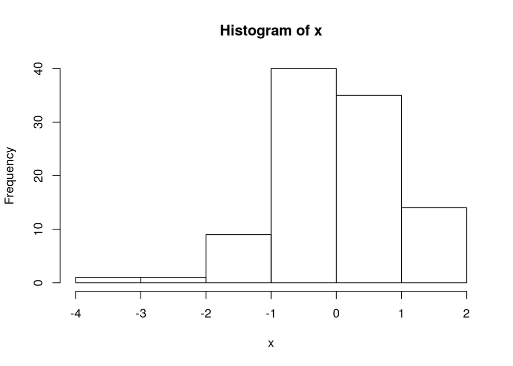

```r
# simple plot
x <- rnorm(100)
hist(x)
```

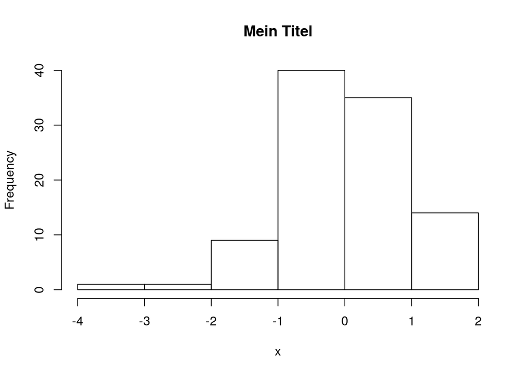

```r
hist(x, main = "Mein Titel")
```

```r
plot(mtcars$hp, mtcars$qsec)

## ggplot2
head(dat) ## mtcars
```

```
##                    mpg cyl disp  hp drat    wt  qsec vs        am gear
## Mazda RX4         21.0   6  160 110 3.90 2.620 16.46  0    manual    4
## Mazda RX4 Wag     21.0   6  160 110 3.90 2.875 17.02  0    manual    4
## Datsun 710        22.8   4  108  93 3.85 2.320 18.61  1    manual    4
## Hornet 4 Drive    21.4   6  258 110 3.08 3.215 19.44  1 automatic    3
## Hornet Sportabout 18.7   8  360 175 3.15 3.440 17.02  0 automatic    3
## Valiant           18.1   6  225 105 2.76 3.460 20.22  1 automatic    3
##                   carb
## Mazda RX4            4
## Mazda RX4 Wag        4
## Datsun 710           1
## Hornet 4 Drive       1
## Hornet Sportabout    2
## Valiant              1
```

[figure not shown]

```r
library(ggplot2)
```

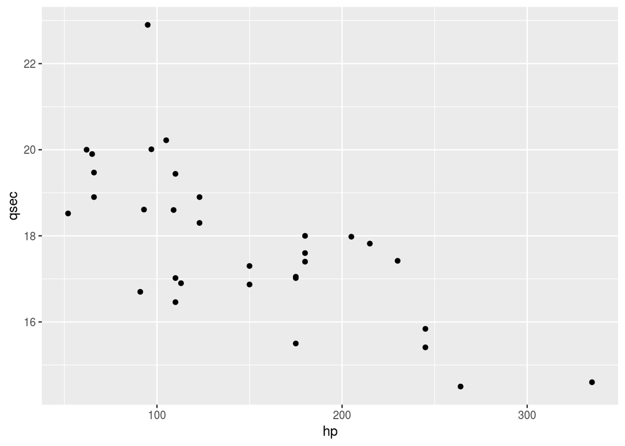

```r
ggplot(data = dat, aes(x=hp, y=qsec)) + geom_point()
```

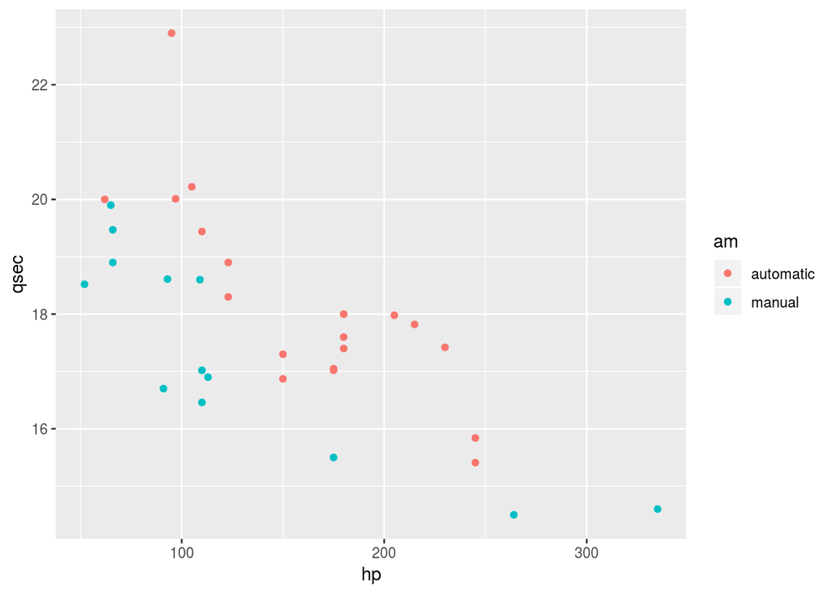

```r
ggplot(data = dat, aes(x=hp, y=qsec)) + geom_point() + aes(color = am)
```

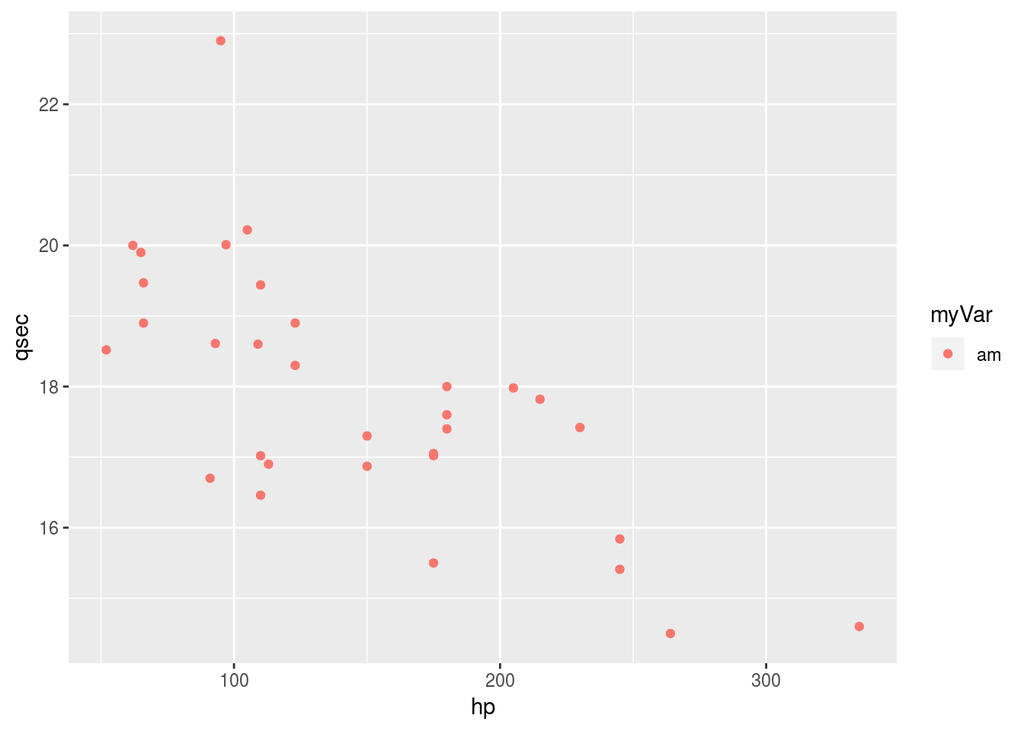

```r
## color by group
myVar <- "am"
ggplot(data = dat, aes(x=hp, y=qsec)) + geom_point() + aes(color = myVar)
```

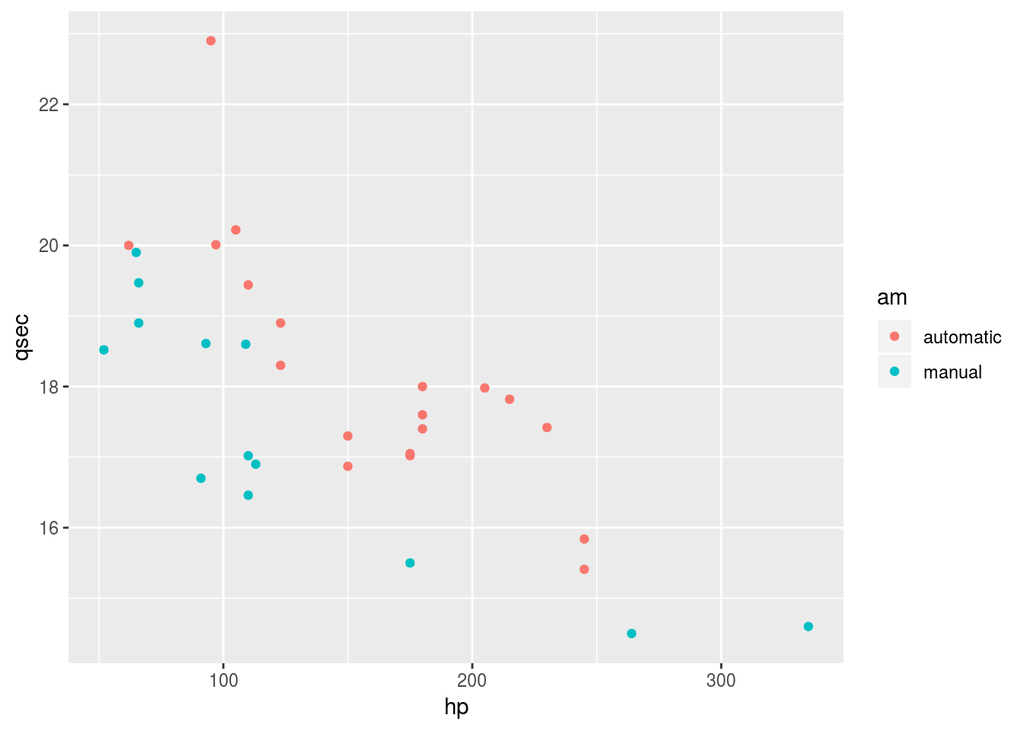

```r
ggplot(data = dat, aes(x=hp, y=qsec)) + geom_point() + aes_string(color = myVar)
```

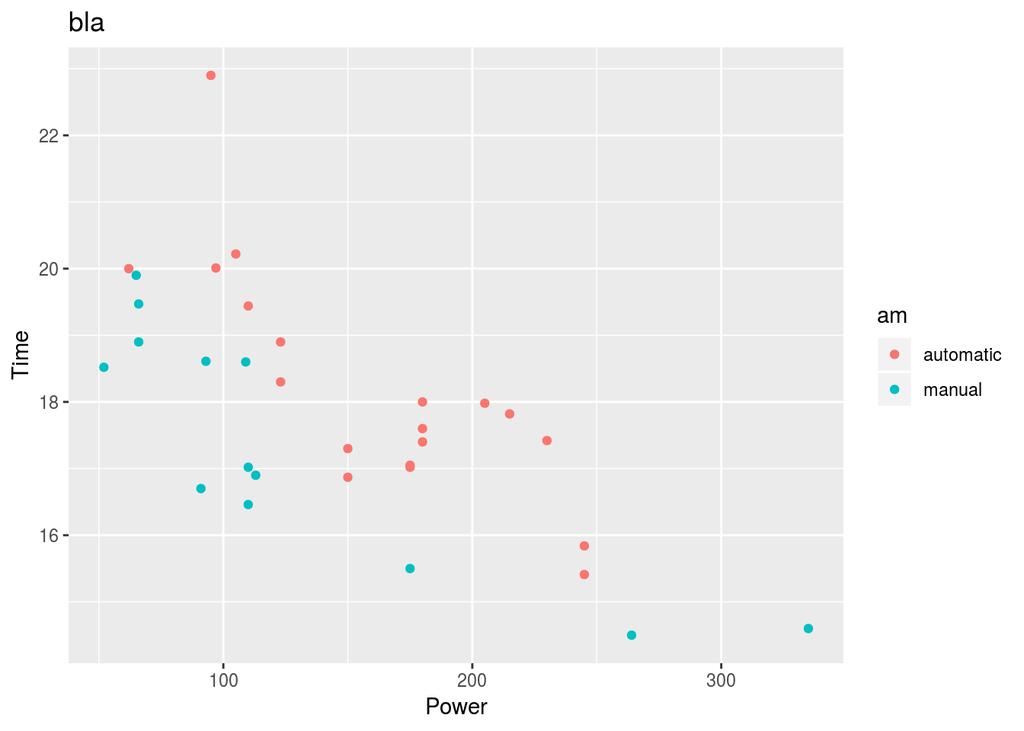

```r
## add labels
ggplot(data = dat, aes(x=hp, y=qsec)) + geom_point() + aes_string(color = myVar) + labs(x="Power", y="Time",title="bla")
```